# Peremptory Strikes and Jury Composition

Peremptory strikes in one Mississippi district, and a pattern no single trial can show

Democracy’s Data

Last updated September 13, 2026 at 10:53a EDT

A jury is the only part of American government staffed by lottery. It exists so that the state’s gravest power, taking a person’s liberty or life, is used by ordinary people rather than professionals. Its authority comes from being drawn out of the community, not picked out of it.

Each side in a trial may remove a fixed number of jurors without giving any reason. That is a **peremptory strike**. (A juror can also be removed **for cause**, for a stated reason the judge accepts, such as knowing a witness, and there is no limit on those.) Since *Batson v. Kentucky* (1986) exactly one reason for a peremptory strike is forbidden: race.[^1] Does race predict who gets struck? A rule against one reason, inside a procedure built on not requiring reasons, can only be enforced by inference, and inference needs a record.

In a Mississippi courtroom in 1992 a prosecutor removed 6 people from a jury **panel**, the group of citizens summoned to the courthouse from whom the twelve are chosen. 15 of the people in that room were his to remove if he wanted them gone, 3 Black and 12 white. He struck all 3 of the Black jurors and 3 of the 12 white ones, and gave no reason for any of them. None was asked of him.

## The test

The records are the jury-selection files of 211 trials in Mississippi’s Fifth Circuit Court District, 1992 to 2015, read out of the courts’ paper files by reporters at APM Reports, the investigative newsroom of American Public Media, and published as plain tables at https://github.com/APM-Reports/jury-data. No court keeps this record. A clerk logs that a juror was excused, and nothing in that file says what race the juror was, because no rule requires it to. The evidence exists because a newsroom built it. Reporters for the second season of the podcast *In the Dark* pulled the paper files of 225 trials and coded every prospective juror by hand.[^2]

Two properties make it the right evidence rather than merely the available evidence. It is juror by juror, so a rate can be computed over the people a side was permitted to remove rather than over everyone in the room. And it records **both** sides’ strikes, which supplies a comparison group nobody had to construct. The defense drew from the same panels, in the same trials, under the same rules, wanting the opposite thing.

These are administrative records: paperwork kept while somebody was running a court, about people who never asked to be described. The section introduction sets out what that kind of file can bear. Such a file usually counts the events an institution acted on and says nothing about the population behind them. This one is the lucky case, because that population is inside the file.

## The data

Everything below reads two small tables. `strikes.csv` has four rows and five columns: `side`, `race`, `eligible`, `struck` and `pct`. `trials.csv` is one row per trial, with `trial`, `black_eligible`, `black_struck`, `white_eligible` and `white_struck`. Both come from APM’s `jurors.csv`, one row per prospective juror per trial, 14,874 rows in all.

[output not shown]

Three decisions in that reduction set what the rates mean.

**The bottom number is eligibility, not attendance.** A rate needs a bottom number to divide by, and here it is the jurors a given side was entitled to strike. APM’s `strike_eligibility` column records that, and nearly half the file reads `n/a`: jurors already removed for cause, or never reached before the twelve seats filled. Counting those would make both sides look far more restrained than they were, and would do it to the two sides unequally. The whole comparison rests on this one column, which most court records do not have.

**Nine outcomes were collapsed into one question.** APM’s `struck_by` tells a juror struck by the state from one struck for cause, one excused, one never noted, and one whose fate is unknown. Only “Struck by the state” and “Struck by the defense” count as a strike here. The 571 jurors struck without notation count as struck by neither side, the conservative choice, and that pushes both rates down.

**Two races were kept and 4,756 jurors were dropped.** Nearly all are jurors whose race the paperwork never recorded, 31.9% of the file. They are unlikely to be a random third, because a juror the record never described is not a random juror. Four more were coded Asian or Latino, too few to compute anything from. A two-category world appears in the output that was not in the input.

One column deserves a sentence of its own, because almost nothing else in this book has one. `race_source` records **how the reporters knew**: off a jury strike sheet for most jurors, off a transcript of the questioning for a couple of hundred, and from other documents for a few dozen. Where a value came from is normally something a reader has to guess at. Here it sits beside the value, which makes the gaps arguable rather than merely present.

Here is the whole of `strikes.csv`:

| Side | Race | Could be struck | Struck | % |
| --- | --- | --- | --- | --- |
| state | Black | 1,811 | 902 | 49.8 |
| state | White | 3,318 | 372 | 11.2 |
| defense | Black | 846 | 127 | 15.0 |
| defense | White | 2,812 | 1,330 | 47.3 |

> **Before you read on, commit to two numbers.** The state struck 49.8% of the Black jurors it was allowed to strike and 11.2% of the white ones. Now the other lawyer in that room. The defense drew from the same panels, wanting the opposite outcome. Write down the share of eligible **white** jurors you think the defense struck, and the share of eligible **Black** ones. Then write down how many of the 211 trials you would expect chance alone to make look lopsided.

## What it says about democracy

Add up every strike that office made over 23 years, by the juror’s race:

| Race | Eligible to be struck | Struck by the state | % struck |
| --- | --- | --- | --- |
| Black | 1,811 | 902 | 49.8 |
| White | 3,318 | 372 | 11.2 |

**The state struck 49.8% of the eligible Black jurors and 11.2% of the eligible white ones**, a ratio of 4.4 to one. There is an answer to that table, and it is not frivolous. Struck jurors differ in ways that have nothing to do with race: a prosecuted relative, a doubt about the death penalty, an acquaintance with a witness. If those are spread unevenly across the community, a race-neutral rule produces a racial gap by itself.

What answers the reply is the other lawyer.

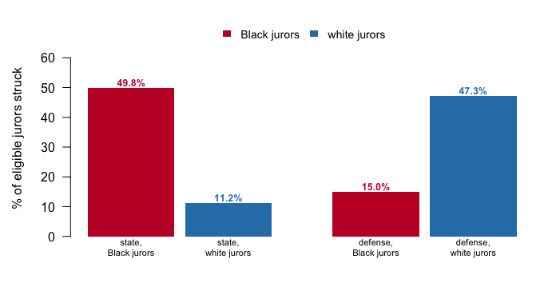

**Figure 1. The two sides strike the same panels in opposite directions.** Four bars, because the claim is about four rates measured on the same jurors, and a bar makes shares comparable at a glance. Across 211 trials the state struck 49.8% of eligible Black jurors and 11.2% of eligible white ones; the defense struck 47.3% of eligible white jurors and 15.0% of eligible Black ones. The two tall bars differ by 2.5 points and the two short ones by 3.8.

**The pattern reverses almost exactly.** Whatever made a Black juror worth striking to the state made a white juror worth striking to the defense at nearly the same rate. The legitimate-characteristics explanation now has to name a trait that is spread unevenly by race *and* valued in precisely opposite directions by the two parties. None has been proposed, in this litigation or in the research it belongs to.

Now ask the question one trial at a time. Take the Black jurors the state could strike and the Black jurors it struck, and work out the chance of a split that lopsided if the strikes had ignored race.

The opening trial shows the arithmetic. The state had 6 strikes to spend among 15 eligible jurors, 3 of them Black. There are 5,005 ways to pick 6 names out of 15, and 220 of those ways take all 3 Black jurors. If race played no part, every way is equally likely, so the chance of a split at least that lopsided is 220 ÷ 5,005 = 4.4%, about one in 23. That chance is the trial’s **p-value**. By long convention a result is called **significant** when its p-value falls below 0.05, one in twenty, and this trial falls just under it.

| Quantity | Value |
| --- | --- |
| Trials significant at p < 0.05 | 99 |
| Expected by chance: the textbook shortcut | 10.6 |
| Expected by chance: simulated from each trial’s own margins | 3.5 |
| Trials significant at p < 0.01 | 51 |
| Trials where every eligible Black juror was struck | 15 |

99 of the 211 trials come in significant at the conventional line. The textbook shortcut says chance alone should produce 10.6 of them, five percent of 211, making the observed count 9 times too high. **That shortcut is wrong here, and wrong in the direction that works against the finding.** These tests run on small whole numbers, so a trial with four eligible Black jurors and three strikes can produce only a handful of possible answers, none of them 0.04. A test whose next available value below 0.11 is 0.03 never fires at 0.05.

So the benchmark was simulated rather than assumed. Redraw every trial’s strikes by lottery, a computer picking the struck names at random from that trial’s own eligible jurors and keeping its strike count, so that race can play no part; do that 2,000 times over, and count how often that imaginary courthouse produces a lopsided trial. Chance produces 3.5 such trials, not 10.6. The observed count is 28 times the honest benchmark. Being careful about the benchmark makes the gap 3 times larger, which is the opposite of what most readers write down.

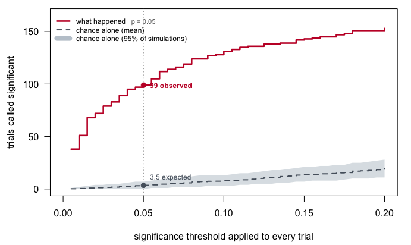

Hover for the count at any threshold.

**Figure 2. The result does not depend on choosing 0.05.** Trials called lopsided at every threshold from 0.005 to 0.2, because a finding that lives at one arbitrary line is not a finding. What happened in this district is drawn against the mean and the middle 95% of 2,000 simulated courthouses. In each of those a trial keeps its own jurors and its own strikes, but race does no work. At the conventional line the counts are 99 against 3.5, and the red line never enters the gray band at any threshold on the axis.

15 of the 211 trials removed every eligible Black juror. The three most lopsided:

| Trial | Black eligible | Black struck | White eligible | White struck | P |
| --- | --- | --- | --- | --- | --- |
| 2003-0071–Curtis Flowers III | 15 | 15 | 21 | 0 | 1.8e-10 |
| 1998-0011C-D–Krishun Williams | 17 | 14 | 29 | 3 | 1.5e-06 |
| 2003-0071–Curtis Flowers IV | 16 | 11 | 20 | 0 | 7.3e-06 |

**The most extreme is the third trial of Curtis Flowers. 15 Black jurors were eligible and 15 were struck; of 21 eligible white jurors, 0 were.** The chance of that split under race-neutral striking is 1.8e-10, which is scientific notation for 1.8 in ten billion, roughly one in 6 billion. Flowers was tried six times for the same crime by the same prosecutor. In *Flowers v. Mississippi* (2019) the Supreme Court threw out his conviction, resting substantially on that pattern across the six trials.[^3] The charges were dropped, and he went home after nearly twenty-three years.[^4]

Notice what it took. Not a statistical argument in one courtroom, and not the mirror in Figure 1, which no judge had ever seen. It took one defendant tried so many times by one office that the career pattern and the single case became the same object. And it took reporters reading paper, because the court never wrote down the fact the rule depends on.

## What this brief cannot tell you

**It cannot win a single case.** *Batson* is litigated before a judge who has seen one panel. The 1992 trial that opens this brief carries a probability of 4.4%, about one chance in 23, which is roughly what an ordinary motion has to work with. It loses, and the rule is enforced at exactly the level where the evidence is weakest.

**It cannot report a reason.** No row records why anyone was struck, because the procedure was designed not to require reasons. The file shows what was done and never what was said, so no explanation a prosecutor offered or a judge accepted is in it.

**It cannot speak for the country.** Mississippi’s Fifth Circuit is one district, read precisely because it produced *Flowers*, which is the strongest possible reason to expect it to be unusual.

**It cannot close the missing third.** Race is unknown for 4,752 of 14,874 jurors, and if that gap were related both to race and to being struck, the rates in Figure 1 would shift. The mirror makes that a stretch, since the same jurors are missing from both sides of it.

**And it says nothing about verdicts.** This is a record of who was excluded, not of what the resulting juries decided.

## What you should have learned

- The state struck 49.8% of eligible Black jurors against 11.2% of eligible white ones, a ratio of 4.4 to one.
- A disparity on its own proves little, and this file answers that objection from inside itself: the defense struck 47.3% of eligible white jurors and 15.0% of eligible Black ones, from the same panels on the same mornings.
- Being careful about a benchmark can make a finding larger. 99 of 211 trials look lopsided, against 10.6 on the textbook shortcut and 3.5 when the chance-alone benchmark is simulated from each trial’s own numbers.
- Aggregate evidence and courtroom evidence are different things: one trial gives 4.4%, while 15 of 211 trials removed every eligible Black juror.
- The record-keeping is part of the finding. No court recorded jurors’ race, a newsroom did it by hand, and outside these 211 trials the question still cannot be answered.

## Extensions

None of these is answered above, and every one can be answered from the tables the Sources section hands over.

- `strikes.csv` has `eligible` and `struck` for each `side` and `race`. Recompute `pct` for all four rows, then the ratio within each side. Which side produces the larger gap?
- `trials.csv` has `black_eligible` and `black_struck`. Compute the share struck in each trial and sort. How many trials sit at zero, and do they cluster in particular years?
- `trials.csv` also carries `white_eligible` and `white_struck`. Compute both shares per trial and count the trials where the white share is higher. Is the district-wide pattern in every trial, or in most of them?
- The `trial` column begins with the year. Group by year and compute the Black strike share. Did the office change over the period?
- **Stretch.** APM published the full juror file too. Download it, count how many jurors each value of `race_source` accounts for, and ask whether the unknowns fall evenly across trials.
- **Stretch.** Studies in Philadelphia, North Carolina and Louisiana measured the same thing. Find one and check whether its strike rates would clear a simulated benchmark rather than the textbook one.

## Sources

**Data**

- APM Reports, *In the Dark* season 2, jury data. https://github.com/APM-Reports/jury-data — `jurors.csv`, `trials.csv` and `voir_dire_answers.csv`, coded from the court records of 225 trials in Mississippi’s Fifth Circuit District, reduced here to the 211 trials with at least ten eligible jurors. The reporting the data came out of: https://features.apmreports.org/in-the-dark/season-two/.

**The data itself**

Every figure above is drawn from these tables. They are plain CSV, they open in a spreadsheet, and they are yours to take further.

`strikes.csv`, `trials.csv`, `flowers.csv`

**Cases and literature**

- *Batson v. Kentucky*, 476 U.S. 79 (1986), including the separate opinion of Justice Thurgood Marshall, who agreed with the result and argued that requiring reasons only teaches lawyers to produce them. https://www.law.cornell.edu/supremecourt/text/476/79
- *Flowers v. Mississippi*, 588 U.S. ___ (2019), No. 17-9572. https://www.law.cornell.edu/supremecourt/text/17-9572
- APM Reports, “Charges against Curtis Flowers are dropped,” 4 September 2020. https://www.apmreports.org/episode/2020/09/04/charges-against-curtis-flowers-are-dropped
- Grosso, C. M. and O’Brien, B. (2012). “A Stubborn Legacy: The Overwhelming Importance of Race in Jury Selection in 173 Post-*Batson* North Carolina Capital Trials.” *Iowa Law Review* 97: 1531–1559.

Rebuild this data yourself, with an AI assistant

```
I want to rebuild a public dataset from its original source, without any
starting files. Please do the following and show your work.

THE SOURCE. APM Reports, the investigative newsroom behind the podcast
"In the Dark", season 2: jury-selection records from 225 trials in
Mississippi's Fifth Circuit Court District over 26 years, read out of
court files by reporters. The data sit in the GitHub repository
APM-Reports/jury-data; download the raw files
https://raw.githubusercontent.com/APM-Reports/jury-data/master/jurors.csv
https://raw.githubusercontent.com/APM-Reports/jury-data/master/trials.csv
No account or key is needed. In the juror file each row is one
prospective juror in one trial — 14,874 of them — with the juror's
race, who was allowed to strike them (strike_eligibility), and who
actually struck them (struck_by). The trial file is one row per court
proceeding, 305 in all.

WHAT TO BUILD.
1. Strike rates by race, separately for the prosecution and the
   defense. Count a juror in a side's denominator only if that side
   could have struck them — a juror removed for cause, or never
   reached, was available to nobody. Use only jurors coded Black or
   White: race is unknown for 4,752 jurors, a third of the file, and
   they have to be left out.
2. A per-trial table: for every trial with at least ten eligible
   jurors of known race, the Black and white jurors the state could
   strike, and how many of each it struck.

CHECK YOUR WORK. The copy this book used was downloaded in August 2026.
If your rebuild matches it, you should find:
- the state struck 902 of 1,811 eligible Black jurors and 372 of
  3,318 eligible white jurors — about 50% against 11%
- the defense ran the mirror image: 127 of 846 Black jurors struck,
  1,330 of 2,812 white
- 211 trials clear the ten-juror bar
The repository is the archive of a finished investigation and rarely
changes; if your counts differ, check whether the newsroom revised the
files before assuming you made an error.
```

[^1]: *Batson v. Kentucky*, 476 U.S. 79 (1986), https://www.law.cornell.edu/supremecourt/text/476/79.
[^2]: APM Reports, *In the Dark*, season two (2018), on the prosecution of Curtis Flowers and the jury-selection record of the district that tried him: https://features.apmreports.org/in-the-dark/season-two/.
[^3]: *Flowers v. Mississippi*, 588 U.S. ___ (2019), No. 17-9572, https://www.law.cornell.edu/supremecourt/text/17-9572.
[^4]: APM Reports, “Charges against Curtis Flowers are dropped,” *In the Dark*, 4 September 2020, https://www.apmreports.org/episode/2020/09/04/charges-against-curtis-flowers-are-dropped.